# Analyzing and Plotting Data

## Learning Objectives

> - understand how to deal with missing data
> - being able to generate summary statistics from the data
> - calculate basic statistics across levels of a factor (here species)
> - generate plots from the data using the average weights of the animals as an example

*If you have not already downloaded the [surveys](http://emudrak.github.io/2015-01-15-cornell/data/biology/surveys.csv) data and put it in directory `"data"` within your working directory, please do so now.*

# Calculating statistics

Let’s get a closer look at our data. For instance, we might want to know how many animals we trapped in each plot, or how many of each species were caught.

The function `table()`, tells us how many of each species we have:

```r
table(surveys$species)
```

R has a lot of built in statistical functions, like `mean()`, `median()`, `max()`, `min()`, `var()`, `sd()`. Let’s start by calculating the average weight of all the animals using the function `mean()`:

```r
mean(surveys$wgt)
```

```
[1] NA
```

Hmm, we just get `NA`. That’s because we don’t have the weight for every animal and missing data is recorded as `NA`. By default, all R functions operating on a vector that contains missing data will return NA. It’s a way to make sure that users know they have missing data, and make a conscious decision on how to deal with it.

When dealing with simple statistics like the mean, the easiest way to ignore `NA` (the missing data) is to use `na.rm=TRUE` (`rm` stands for remove):

```r
mean(surveys$wgt, na.rm=TRUE)
```

```
[1] 42.67243
```

In some cases, it might be useful to remove the missing data from the vector. For this purpose, R comes with the function `na.omit`:

```r
wgt_noNA <- na.omit(surveys$wgt)
```

For some applications, it’s useful to keep all observations, for others, it might be best to remove all observations that contain missing data. The function `complete.cases()` removes any rows that contain at least one missing observation:

```r
surveys_complete <- surveys[complete.cases(surveys), ]
```

**Note**: What this is actually doing is rather interesting. The simple line

```r
complete.cases(surveys)
```

returns a list of `TRUE`/`FALSE` values for each row of `surveys`, showing whether or not it is a complete case. When you put such a list into the brackets `[,]` to index a matrix, it returns the rows that are listed as `TRUE`.

The new data.frame `surveys_complete` now has only complete data. Lets see how many observations of each species was retained:

```r
table(surveys_complete$species)
```

Many species have 0 values in this table, meaning there are no records of this species left (i.e. none had the weight recorded). Yet they still show up in this table. This is because R “remembers” all species that were found in the original dataset, even though they aren’t included in this data set. This could get annoying later on (with plotting, etc…).

To remove the `NA` and make things clearer, we can redefine the levels for the factor “species” by re-establishing this as a factor.

```r
surveys_complete$species <- factor(surveys_complete$species)
```

An equivalent way to do this is to use the droplevels() function. This will work if you have many columns from the same data frame that need excess factors removed.

```r
surveys_complete <- droplevels(surveys_complete)
```

Now see how things are looking:

```r
table(surveys_complete$species)
```

## PAUSE

Make sure everyone has a clean copy of surveys_complete.

If you have been lost/confused/in the bathroom, you can catch up now with:

```r
##CLEAR WORKPACE????

#surveys <- read.csv('data/surveys.csv')
surveys$logwgt <- log(surveys$wgt)
surveys$plot <- as.factor(surveys$plot)
surveys_complete <- surveys[complete.cases(surveys), ]
surveys_complete <- droplevels(surveys_complete)
```

**Now save the script!**

### Challenge

1. To determine the number of elements found in a vector, we can use use the function `length()` (e.g., `length(surveys$wgt)`). Using `length()`, how many animals have not had their weights recorded?
2. What is the range (minimum and maximum) weight?
3. What is the median weight for the males?

# Statistics across factor levels

What if we want the maximum weight for each species, or the mean for each plot?

R comes with convenient functions to do this kind of operations, functions in the `apply` family.

For instance, `tapply()` allows us to repeat a function across each level of a factor. The format is:

`tapply(columns_to_do_the_calculations_on, factor_to_sort_on, function)`

If we want to calculate the maximum for each species (using the complete dataset):

```r
tapply(surveys_complete$wgt, surveys_complete$species, max)
```

If we want to calculate the mean for each plot:

```r
tapply(surveys_complete$wgt, surveys_complete$plot, mean)
```

### Challenge

1. Create new objects to store: the standard deviation, the maximum and minimum values for the weight of each species
2. How many species do you have these statistics for?
3. Create a new data frame (called `surveys_summary`) that contains as columns:
- `species` the 2 letter code for the species names
- `mean_wgt` the mean weight for each species
- `sd_wgt` the standard deviation for each species
- `min_wgt` the minimum weight for each species
- `max_wgt` the maximum weight for each species

**Answers**

```r
species_max <- tapply(surveys_complete$wgt, surveys_complete$species, max)
species_min <- tapply(surveys_complete$wgt, surveys_complete$species, min)
species_mean <- tapply(surveys_complete$wgt, surveys_complete$species, min)
species_sd <- tapply(surveys_complete$wgt, surveys_complete$species, sd)
nlevels(surveys_complete$species) # or length(species_mean)
surveys_summary <- data.frame(species=levels(surveys_complete$species),
                              mean_wgt=species_mean,
                              sd_wgt=species_sd,
                              min_wgt=species_min,
                              max_wgt=species_max)
```

# Creating a barplot

The best way to develop insight is often to visualize data. Visualization deserves an entire lecture (or course) of its own, but we can explore a few features of R’s base plotting package.

Let’s use the `surveys_summary` data that we generated and plot it. R has built in plotting functions.

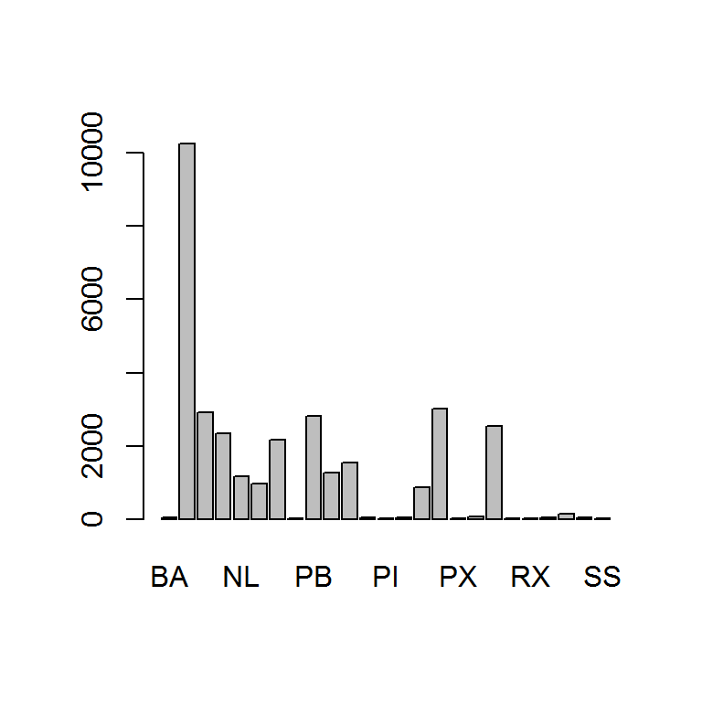

```r
barplot(table(surveys_complete$species))
```

The axis labels are too big though, so you can’t see them all. Let’s change that.

> **Tip:** To learn about a function in R, e.g. `barplot`, we can read its help documention by running `help(barplot)` or `?barplot`.

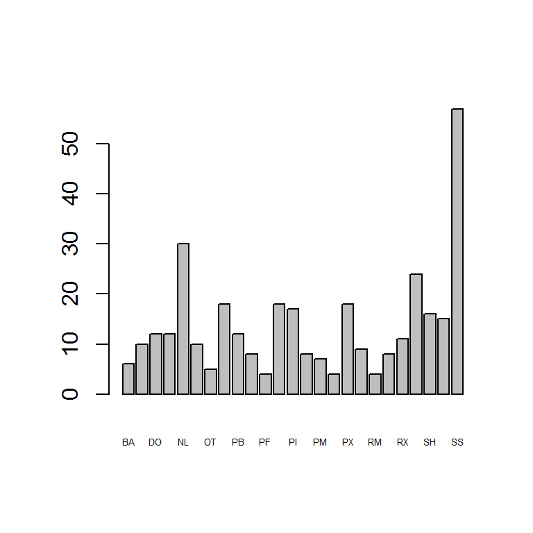

```r
barplot(surveys_summary$mean_wgt, cex.names=0.4)
```

Alternatively, we may want to flip the axes to have more room for the species names:

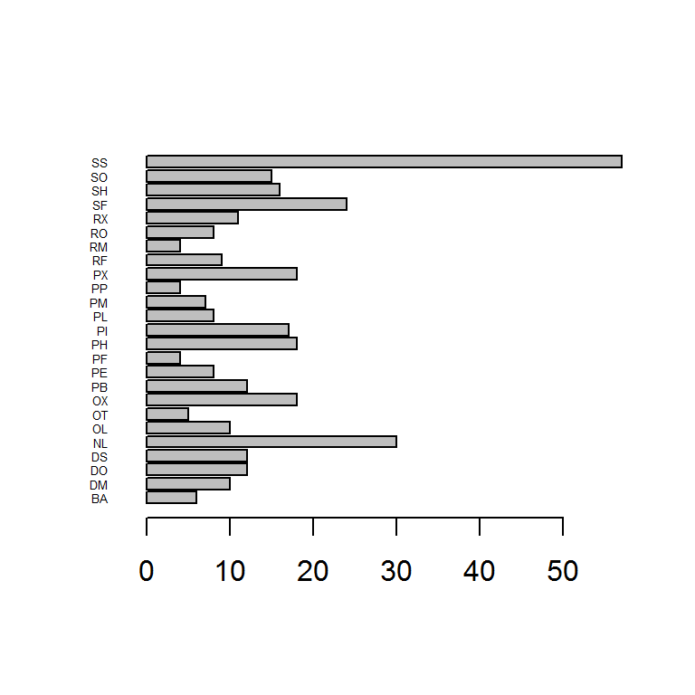

```r
barplot(surveys_summary$mean_wgt, horiz=TRUE, las=1, cex.names=0.4)
```

Let’s also add some colors, and add a main title, label the axis:

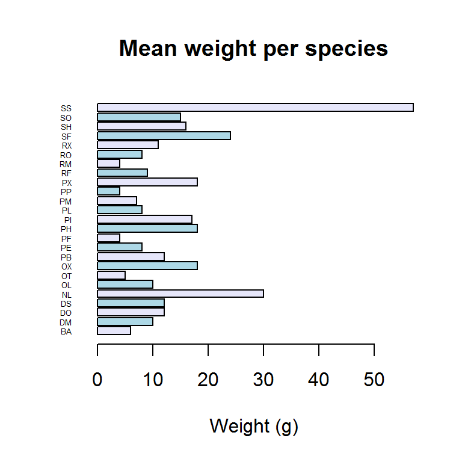

```r
barplot(surveys_summary$mean_wgt, horiz=TRUE, las=1, cex.names=0.4,
        col=c("lavender", "lightblue"), xlab="Weight (g)",
        main="Mean weight per species")
```

### Challenge

1. Create a new plot showing the standard deviation for each species. Choose one or more colors from [here](http://www.stat.columbia.edu/~tzheng/files/Rcolor.pdf). (If you prefer, you can also specify colors using their hexadecimal values `#RRGGBB`.)

## More about plotting

There are lots of different ways to plot things. You can do `plot(object)` for most classes included in R base. To explore some of the possibilities:

```r
?barplot
?boxplot
?plot.default
example(barplot)
```

If you wanted to output this plot to a pdf file rather than to the screen, you can specify where you want the plot to go with the `pdf()` function. If you wanted it to be a JPG, you would use the function `jpeg()` (other formats available: svg, png, ps).

Be sure to add `dev.off()` at the end to finalize the file. For `pdf()`, you can create multiple pages to your file, by generating multiple plots before calling `dev.off()`.

```r
jpeg("mean_per_species.jpg", height=400, width=500)
barplot(surveys_summary$mean_wgt, horiz=TRUE, las=1,
        col=c("lavender", "lightblue"), xlab="Weight (g)",
        main="Mean weight per species")
dev.off()
```

```r
pdf("mean_per_species.pdf")
barplot(surveys_summary$mean_wgt, horiz=TRUE, las=1,
        col=c("lavender", "lightblue"), xlab="Weight (g)",
        main="Mean weight per species")
dev.off()
```

#### Key Points

- Use `variable <- value` to assign a value to a variable in order to record it in memory.
- Objects are created on demand whenever a value is assigned to them.
- The function `dim` gives the dimensions of a data frame.
- Use `object[x, y]` to select a single element from a data frame.
- Use `from:to` to specify a sequence that includes the indices from `from` to `to`.
- All the indexing and slicing that works on data frames also works on vectors.
- Use `#` to add comments to programs.
- Use `mean`, `max`, `min` and `sd` to calculate simple statistics.
- Use `apply` to calculate statistics across the rows or columns of a data frame.
- Use `plot` to create simple visualizations.

Previous:The data.frame class Next: Writing Functions